# Семинар 7. Классификация

Июнь, 19, 2018

Шаманское заклинание для настройки глобальных опций отчёта:

```r
library(tidyverse) # обработка данных, графики...
library(skimr) # описательные статистики
library(rio) # импорт фантастического количества форматов данных
library(broom) # метла превращает результаты оценивания моделей в таблички
library(Ecdat) # много-много разных наборов данных
library(ISLR) # ещё данные
library(sandwich) # оценка Var для гетероскедастичности
library(caret) # пакет для подбора параметров разных моделей
library(FFTrees) # быстрые деревья
library(margins) # для подсчёта предельных эффектов
library(rpart.plot) # для картинок деревьев
library(plotROC) # визуализация ROC-кривой
library(ggeffects) # графики для предельных эффектов
library(MLmetrics) # метрики качества
```

Импортируем набор данных по успеваемости студентов и смотрим на него :)

```r
educ <- import('xAPI-Edu-Data.csv')
skim(educ)
```

```
## Skim summary statistics
##  n obs: 480
##  n variables: 17
##
## Variable type: character
##                  variable missing complete   n min max empty n_unique
##                     Class       0      480 480   1   1     0        3
##                    gender       0      480 480   1   1     0        2
##                   GradeID       0      480 480   4   4     0       10
##               NationalITy       0      480 480   2  11     0       14
##     ParentAnsweringSurvey       0      480 480   2   3     0        2
##  ParentschoolSatisfaction       0      480 480   3   4     0        2
##              PlaceofBirth       0      480 480   3  11     0       14
##                  Relation       0      480 480   3   6     0        2
##                 SectionID       0      480 480   1   1     0        3
##                  Semester       0      480 480   1   1     0        2
##                   StageID       0      480 480  10  12     0        3
##        StudentAbsenceDays       0      480 480   7   7     0        2
##                     Topic       0      480 480   2   9     0       12
##
## Variable type: integer
##           variable missing complete   n  mean    sd p0   p25 p50 p75 p100
##  AnnouncementsView       0      480 480 37.92 26.61  0 14     33  58   98
##         Discussion       0      480 480 43.28 27.64  1 20     39  70   99
##        raisedhands       0      480 480 46.77 30.78  0 15.75  50  75  100
##   VisITedResources       0      480 480 54.8  33.08  0 20     65  84   99
##      hist
##  ▇▆▅▅▅▃▃▂
##  ▇▇▇▇▃▅▅▃
##  ▇▆▃▃▃▆▆▃
##  ▆▃▂▁▃▃▇▇
```

Данные взяты с [kaggle.com](https://www.kaggle.com/aljarah/xAPI-Edu-Data/). Целевая переменная — успеваемость студента, `Class`, принимает три значения, ‘H’ (high), ‘M’ (mid), ‘L’ (low). Остальные переменные — характеристики студента.

Для целей бинарной классификации объединяем две верхних категории в одну:

```r
educ_logit <- mutate(educ, y = fct_collapse(Class, H = c('M', 'H')))
```

И объявляем все текстовые переменные факторными:

```r
educ_fct <- mutate_if(educ_logit, is.character, factor)
```

Разделим выборку на две части, обучающую и тестовую. По тестовой мы сможем оценить качество прогнозов нашей модели.

Разбиение выборки на две части — это случаная операция, поэтому зададим на удачу зерно генератора случайных чисел.

Создадим вектор `train_rows` с номерами строк для обучающей части.

```r
set.seed(777)
train_rows <- createDataPartition(educ_fct$y, p = 0.8, list = FALSE)
```

И разделим выборку согласно вектору `train_rows`:

```r
educ_train <- educ_fct[train_rows, ]
educ_test <- educ_fct[-train_rows, ]
```

- Упражнение 1.

Разделите набор данных `Default` из пакета `ISLR` на обучающую и тестовую выборки так, чтобы в первую попало 70% всех наблюдений.

```r
def <- Default
glimpse(def)
```

```
## Observations: 10,000
## Variables: 4
## $ default <fct> No, No, No, No, No, No, No, No, No, No, No, No, No, No...
## $ student <fct> No, Yes, No, No, No, Yes, No, Yes, No, No, Yes, Yes, N...
## $ balance <dbl> 729.5265, 817.1804, 1073.5492, 529.2506, 785.6559, 919...
## $ income  <dbl> 44361.625, 12106.135, 31767.139, 35704.494, 38463.496,...
```

```r
train_rows <- createDataPartition(def$default, p = 0.7, list = FALSE)
def_train <- def[train_rows, ]
def_test <- def[-train_rows, ]
```

# 1 Логистическая регрессия

С помощью метода максимального правдоподобия оценивается модель

$$y_i =
\begin{cases}
1, \text{ если } y^*_i \geq 0; \\
0, \text{ иначе.}
\end{cases}$$

$$y_i^* = \beta_1 + \beta_2 x_i + \beta_3 z_i + u_i,$$
где $u_i$ имеет специальное логистическое распределение.

Также модель можно записать в виде:

$$\frac{\ln P(y_i = 1)}{\ln P(y_i = 0)} = \beta_1 + \beta_2 x_i + \beta_3 z_i$$

Реализуем логистическую регрессию с помощью функции `glm`. Передадим ей набор данных `educ_train`, формулу и укажем специалный аргумент `family = binomial(link = 'logit')`. Сохраним результаты оценивания в переменную `educ_lmodel` и посмотрим на них.

```r
educ_lmodel_glm <- glm(data = educ_train, y ~ gender + SectionID + raisedhands, family = binomial(link = 'logit'))
summary(educ_lmodel_glm)
```

```
##
## Call:
## glm(formula = y ~ gender + SectionID + raisedhands, family = binomial(link = "logit"),
##     data = educ_train)
##
## Deviance Residuals:
##     Min       1Q   Median       3Q      Max
## -1.8009  -0.4881  -0.1803   0.6427   3.2122
##
## Coefficients:
##              Estimate Std. Error z value Pr(>|z|)
## (Intercept)  0.745737   0.365406   2.041  0.04127 *
## genderM      1.004068   0.335521   2.993  0.00277 **
## SectionIDB  -0.348347   0.319917  -1.089  0.27621
## SectionIDC  -0.702561   0.601374  -1.168  0.24270
## raisedhands -0.069383   0.008099  -8.567  < 2e-16 ***
## ---
## Signif. codes:  0 '***' 0.001 '**' 0.01 '*' 0.05 '.' 0.1 ' ' 1
##
## (Dispersion parameter for binomial family taken to be 1)
##
##     Null deviance: 445.18  on 384  degrees of freedom
## Residual deviance: 271.91  on 380  degrees of freedom
## AIC: 281.91
##
## Number of Fisher Scoring iterations: 6
```

- Какие коэффициенты значимы на уровне значимости $\alpha = 0.01$?
- Упражнение 2.

Оцените вероятность не возврата кредита `default` в зависимости от всех остальных факторов в наборе данных `def`.

```r
def_lmodel_glm <- glm(data = def_train, default ~ ., family = binomial(link = 'logit'))
summary(def_lmodel_glm)
```

```
##
## Call:
## glm(formula = default ~ ., family = binomial(link = "logit"),
##     data = def_train)
##
## Deviance Residuals:
##     Min       1Q   Median       3Q      Max
## -2.3813  -0.1512  -0.0623  -0.0237   3.6689
##
## Coefficients:
##               Estimate Std. Error z value Pr(>|z|)
## (Intercept) -1.048e+01  5.612e-01 -18.668   <2e-16 ***
## studentYes  -5.418e-01  2.778e-01  -1.950   0.0511 .
## balance      5.457e-03  2.626e-04  20.783   <2e-16 ***
## income       4.056e-06  9.549e-06   0.425   0.6710
## ---
## Signif. codes:  0 '***' 0.001 '**' 0.01 '*' 0.05 '.' 0.1 ' ' 1
##
## (Dispersion parameter for binomial family taken to be 1)
##
##     Null deviance: 2050.6  on 7000  degrees of freedom
## Residual deviance: 1145.3  on 6997  degrees of freedom
## AIC: 1153.3
##
## Number of Fisher Scoring iterations: 8
```

Чтобы найти предельные эффекты, воспользуемся функцией `margins` из одноимённого пакета. Снова выведем результаты командой `summary()`.

```r
educ_margins <- margins(educ_lmodel_glm)
summary(educ_margins)
```

```
##       factor     AME     SE        z      p   lower   upper
##      genderM  0.1173 0.0377   3.1130 0.0019  0.0434  0.1912
##  raisedhands -0.0079 0.0005 -16.7717 0.0000 -0.0089 -0.0070
##   SectionIDB -0.0399 0.0364  -1.0964 0.2729 -0.1111  0.0314
##   SectionIDC -0.0790 0.0648  -1.2194 0.2227 -0.2060  0.0480
```

По умолчанию считается средний предельный эффект. Если нужно подсчитать предельный эффект для конкретного наблюдения, например, для среднего, то можно воспользоваться опцией `at`.

Предельные эффекты тоже можно визуализировать! Эта функция реализована в пакете `ggeffects` и называетя `ggpredict`. Ей нужно передать оценённую модель и указать переменные для визуализации в аргументе `terms`.

```r
pred_educ_vis <- ggpredict(educ_lmodel_glm, terms = c('raisedhands', 'gender'))
pred_educ_vis <- plot(pred_educ_vis)
```

- Упражнение 3.

Оцените предельные эффекты для модели `def_lmodel_glm`. Визуализируйте предельный эффекта для баланса кредитной карты `balance` отдельно для студентов `student` и всех остальных.

```r
def_margins <- margins(def_lmodel_glm)
summary(def_margins)
```

```
##      factor     AME     SE       z      p   lower   upper
##     balance  0.0001 0.0000 20.7360 0.0000  0.0001  0.0001
##      income  0.0000 0.0000  0.4241 0.6715 -0.0000  0.0000
##  studentYes -0.0115 0.0057 -2.0232 0.0431 -0.0227 -0.0004
```

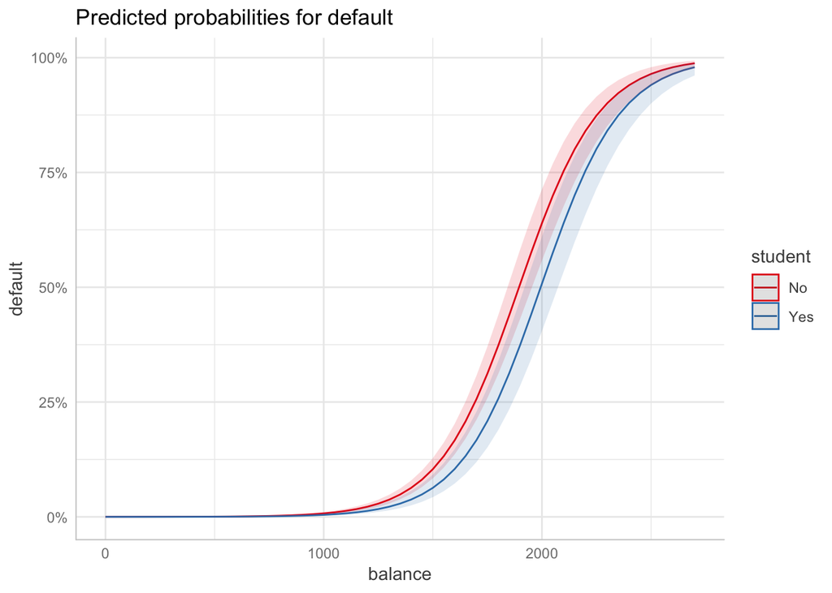

```r
pred_def_vis <- ggpredict(def_lmodel_glm, terms = c('balance', 'student'))
plot(pred_def_vis)
```

Оценивать логистическую модель также можно с помощью пакета `caret`. Изменения минимальные:

```r
educ_lmodel <- train(data = educ_train, y ~ gender + SectionID + raisedhands, family = binomial(link = 'logit'), method = 'glm')
summary(educ_lmodel)
```

```
##
## Call:
## NULL
##
## Deviance Residuals:
##     Min       1Q   Median       3Q      Max
## -1.8009  -0.4881  -0.1803   0.6427   3.2122
##
## Coefficients:
##              Estimate Std. Error z value Pr(>|z|)
## (Intercept)  0.745737   0.365406   2.041  0.04127 *
## genderM      1.004068   0.335521   2.993  0.00277 **
## SectionIDB  -0.348347   0.319917  -1.089  0.27621
## SectionIDC  -0.702561   0.601374  -1.168  0.24270
## raisedhands -0.069383   0.008099  -8.567  < 2e-16 ***
## ---
## Signif. codes:  0 '***' 0.001 '**' 0.01 '*' 0.05 '.' 0.1 ' ' 1
##
## (Dispersion parameter for binomial family taken to be 1)
##
##     Null deviance: 445.18  on 384  degrees of freedom
## Residual deviance: 271.91  on 380  degrees of freedom
## AIC: 281.91
##
## Number of Fisher Scoring iterations: 6
```

- Упражнение 4.

Оцените заново логистическую регессию по набору данных `def` с помощью функций пакета `caret`.

```r
def_lmodel <- train(data = def_train, default ~ ., family = binomial(link = 'logit'), method = 'glm')
summary(def_lmodel)
```

```
##
## Call:
## NULL
##
## Deviance Residuals:
##     Min       1Q   Median       3Q      Max
## -2.3813  -0.1512  -0.0623  -0.0237   3.6689
##
## Coefficients:
##               Estimate Std. Error z value Pr(>|z|)
## (Intercept) -1.048e+01  5.612e-01 -18.668   <2e-16 ***
## studentYes  -5.418e-01  2.778e-01  -1.950   0.0511 .
## balance      5.457e-03  2.626e-04  20.783   <2e-16 ***
## income       4.056e-06  9.549e-06   0.425   0.6710
## ---
## Signif. codes:  0 '***' 0.001 '**' 0.01 '*' 0.05 '.' 0.1 ' ' 1
##
## (Dispersion parameter for binomial family taken to be 1)
##
##     Null deviance: 2050.6  on 7000  degrees of freedom
## Residual deviance: 1145.3  on 6997  degrees of freedom
## AIC: 1153.3
##
## Number of Fisher Scoring iterations: 8
```

Посторим прогнозы модели для тестовых данных `educ_test`. Для этого будем использовать функцию `predict`, которой передадим оценённую модель `educ_lmodel`. В переменной `educ_predz` уже будут лежать предсказанные классы. Чтобы получить их вероятности, нужно добавить аргумент `type = 'prob'`.

```r
educ_pred <- predict(educ_lmodel, newdata = educ_test)
head(educ_pred)
```

```
## [1] L H L H H L
## Levels: H L
```

```r
educ_prob <- predict(educ_lmodel, newdata = educ_test, type = 'prob')
head(educ_prob)
```

```
##            H         L
## 25 0.1975849 0.8024151
## 31 0.8432553 0.1567447
## 37 0.3001891 0.6998109
## 45 0.8240289 0.1759711
## 50 0.7801183 0.2198817
## 55 0.2855258 0.7144742
```

- Упражнение 5.

Постройте прогнозы для тестовой выборки `def_test`. Сохраните как предсказанные классы, так и их вероятности.

```r
def_pred <- predict(def_lmodel, newdata = def_test)
head(def_pred)
```

```
## [1] No No No No No No
## Levels: No Yes
```

```r
def_prob <- predict(def_lmodel, newdata = def_test, type = 'prob')
head(def_prob)
```

```
##           No          Yes
## 2  0.9985137 0.0014863447
## 3  0.9888977 0.0111023380
## 4  0.9994151 0.0005848639
## 5  0.9976080 0.0023920164
## 6  0.9974519 0.0025481033
## 13 0.9998847 0.0001152535
```

Теперь мы можем посмотреть на матрицу ошибок и узнать, насколько хорошую модель мы оецнили. Для этого будем использовть функцию `confusionMatrix` из пакета `caret`. В качестве аргумента `data` нужно указать предсказанные значения, а в `reference` — правильные ответы.

```r
confusionMatrix(data = educ_pred, reference = educ_test$y)
```

```
## Confusion Matrix and Statistics
##
##           Reference
## Prediction  H  L
##          H 65  8
##          L  5 17
##
##                Accuracy : 0.8632
##                  95% CI : (0.7774, 0.9251)
##     No Information Rate : 0.7368
##     P-Value [Acc > NIR] : 0.002303
##
##                   Kappa : 0.633
##  Mcnemar's Test P-Value : 0.579100
##
##             Sensitivity : 0.9286
##             Specificity : 0.6800
##          Pos Pred Value : 0.8904
##          Neg Pred Value : 0.7727
##              Prevalence : 0.7368
##          Detection Rate : 0.6842
##    Detection Prevalence : 0.7684
##       Balanced Accuracy : 0.8043
##
##        'Positive' Class : H
##
```

- Упражнение 6.

Составьте матрицу ошибок для прогнозов модели `def_lmodel`.

```r
confusionMatrix(data = def_pred, reference = def_test$default)
```

```
## Confusion Matrix and Statistics
##
##           Reference
## Prediction   No  Yes
##        No  2891   67
##        Yes    9   32
##
##                Accuracy : 0.9747
##                  95% CI : (0.9684, 0.98)
##     No Information Rate : 0.967
##     P-Value [Acc > NIR] : 0.008743
##
##                   Kappa : 0.4464
##  Mcnemar's Test P-Value : 6.22e-11
##
##             Sensitivity : 0.9969
##             Specificity : 0.3232
##          Pos Pred Value : 0.9773
##          Neg Pred Value : 0.7805
##              Prevalence : 0.9670
##          Detection Rate : 0.9640
##    Detection Prevalence : 0.9863
##       Balanced Accuracy : 0.6601
##
##        'Positive' Class : No
##
```

Чтобы получичть и другие метрики качества для нашей модели, будем использовать функции `twoClassSummary()` и `prSummary()`. Первая возвращает значения ROC, специфичности и чувствительности.

ROC — это площадь под кривой, построенной в осях доли правильных положительных ответов и доли неправильных положительных ответов в зависимости от значения порога для попадания в положительный класс.

Вторая функция возвращает AUC, полноту, точность и F-меру.

AUC — это площадь под кривой, построенной в осях точность-полнота. Точность — это доля объектов на самом деле принадлежащих к положительному классу среди всех объектов, которых модель отнесла к положительному классу.
$$precision = TP / (TP + FP)$$

А F-мера — это среднее гармоническое между точностью и полнотой.

Однако обе функции требуют, чтобы во данных были столбцы с вероятностями классов под названиями самих этих классов, истинные ответы под названием `obs`, и бинарные предсказания, названные как `pred`. Поэтому создадим отдельную таблицу `educ_test_set` со всеми результатами оценивания.

```r
educ_test_set <- data.frame(H = educ_prob$H,
                        L = educ_prob$L,
                        pred = educ_pred,
                        obs = educ_test$y)
glimpse(educ_test_set)
```

```
## Observations: 95
## Variables: 4
## $ H    <dbl> 0.1975849, 0.8432553, 0.3001891, 0.8240289, 0.7801183, 0....
## $ L    <dbl> 0.802415134, 0.156744738, 0.699810922, 0.175971069, 0.219...
## $ pred <fct> L, H, L, H, H, L, H, L, L, H, L, L, H, H, L, H, H, H, H, ...
## $ obs  <fct> L, H, L, H, H, L, H, L, L, H, H, L, H, H, L, H, L, H, L, ...
```

```r
twoClassSummary(educ_test_set, lev = levels(educ_test_set$obs)) # don't work with tibble
```

```
##       ROC      Sens      Spec
## 0.9037143 0.9285714 0.6800000
```

```r
prSummary(educ_test_set, lev = levels(educ_test_set$obs)) # нужен пакет MLmetrics
```

```
##       AUC Precision    Recall         F
## 0.9300243 0.8904110 0.9285714 0.9090909
```

- Упражнение 7.

Выведите характеристики модели `def_lmodel` с помощью функций `twoClassSummary()` и `prSummary()`.

```r
def_test_set <- data.frame(No = def_prob$No,
                           Yes = def_prob$Yes,
                           pred = def_pred,
                           obs = def_test$default)

twoClassSummary(def_test_set, lev = levels(def_test_set$obs))
```

```
##       ROC      Sens      Spec
## 0.9607524 0.9968966 0.3232323
```

```r
prSummary(def_test_set, lev = levels(def_test_set$obs))
```

```
##       AUC Precision    Recall         F
## 0.9982003 0.9773496 0.9968966 0.9870263
```

Почти все метрики можно визуализировать! Но для примера мы построим ROC-кривую. Для этого вдобавок к базовому cлою `ggplot` мы будем использовать слой `geom_roc` из пакета `plotROC`. В эстетиках нужно указать аргументы `d` — истинные значения — и `m` — метки класса 1. Если добавить аргумент `color`, то можно получить разные ROC-кривые по категориям какой-нибудь переменной.

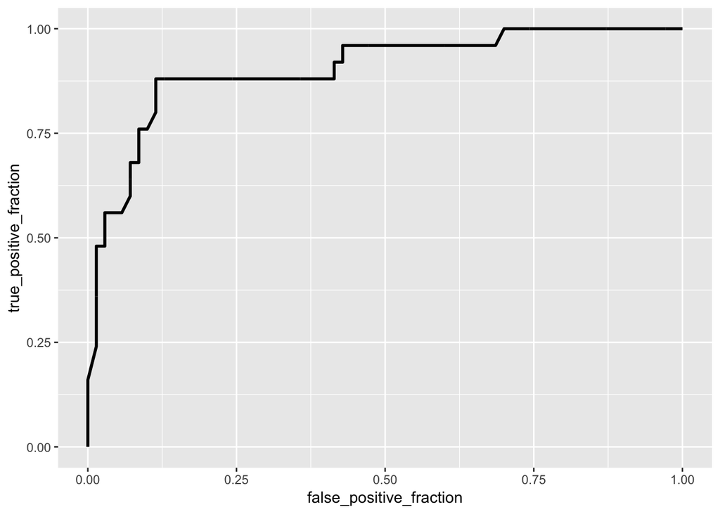

```r
ggplot(educ_test_set, aes(d = obs, m = L)) +
  geom_roc(n.cuts = 0)
```

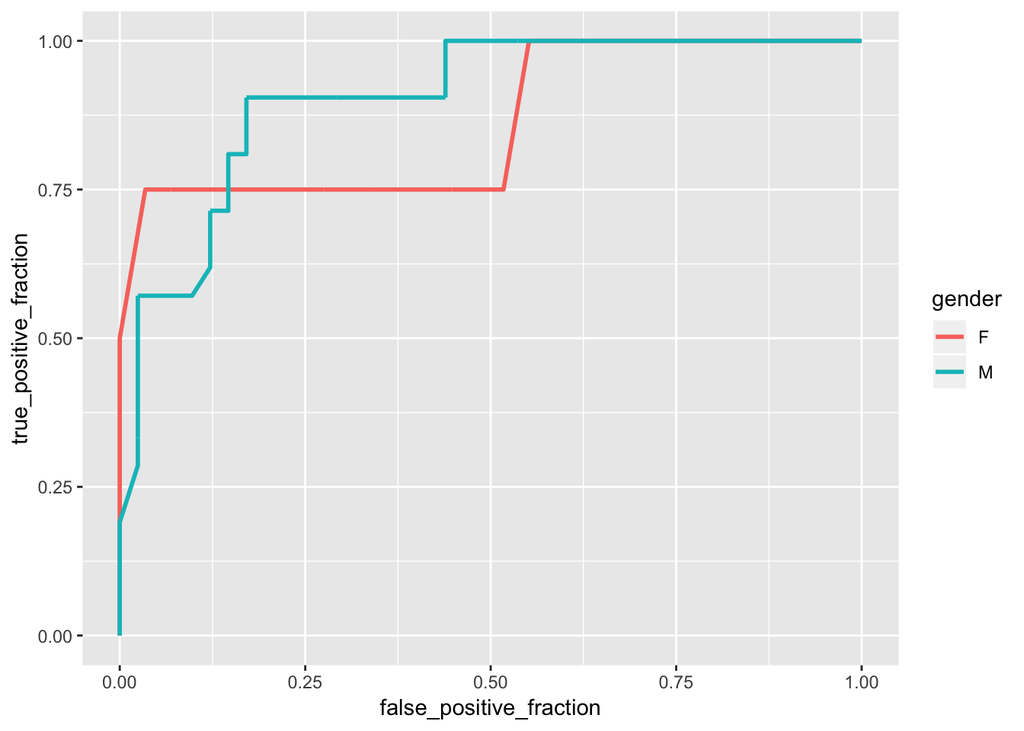

```r
educ_test_set <- mutate(educ_test_set, gender = educ_test$gender)

ggplot(educ_test_set, aes(d = obs, m = L, color = gender)) +
  geom_roc(n.cuts = 0)
```

- Упражнение 8.

Визуализируйте ROC-кривую для прогнозов модели `def_lmodel`. Сначала общую, а затем отдельно для студентов и всех остальных.

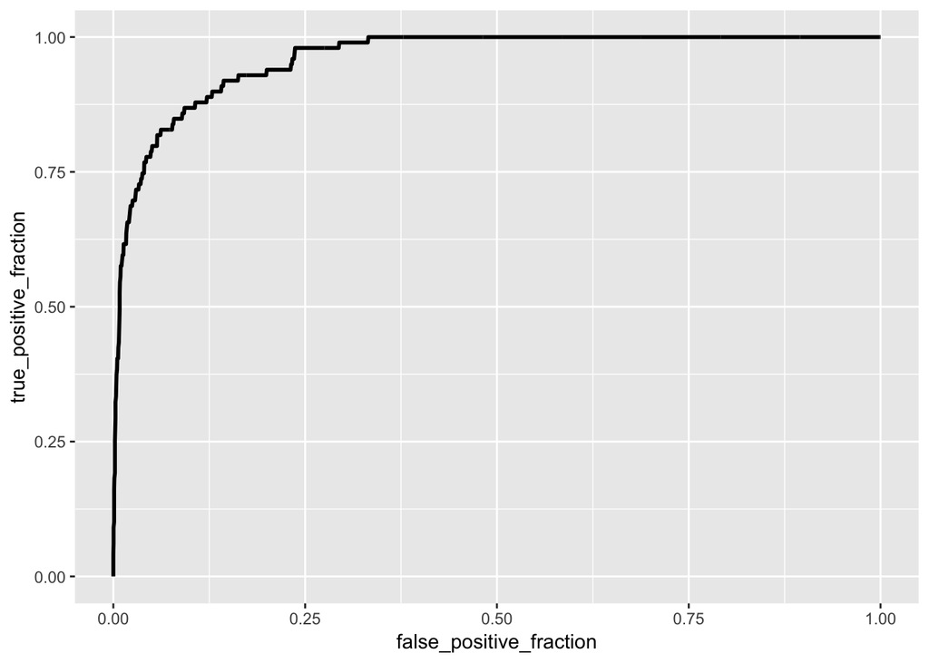

```r
ggplot(def_test_set, aes(d = obs, m = Yes)) +
  geom_roc(n.cuts = 0)
```

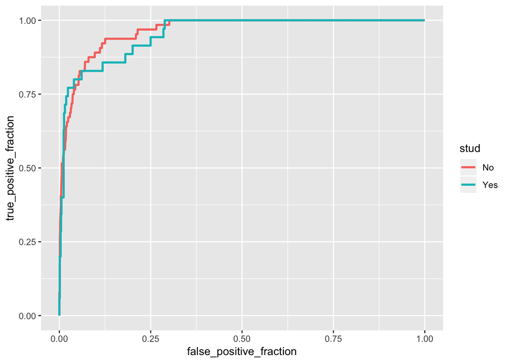

```r
def_test_set <- mutate(def_test_set, stud = def_test$student)

ggplot(def_test_set, aes(d = obs, m = Yes, color = stud)) +
  geom_roc(n.cuts = 0)
```

# 2 На природу, к деревьям и в лес!

Бинарные деревья очень легко интепретируются при приемлемом качестве прогнозов.

Алгоритмы построения дерева отличаются деталями:

- по какому критерию делить веточку на две?
- когда остановить процесс деления веточек?
- следует ли обрезать дерево после окончания деления?
- как обрабатывать пропущенные значений?

```r
tree_model <- train(y ~ . - Class, data = educ_test,
                      method = 'rpart2',
                      na.action = na.omit)
```

```
## note: only 2 possible values of the max tree depth from the initial fit.
##  Truncating the grid to 2 .
```

Картинка дерева:

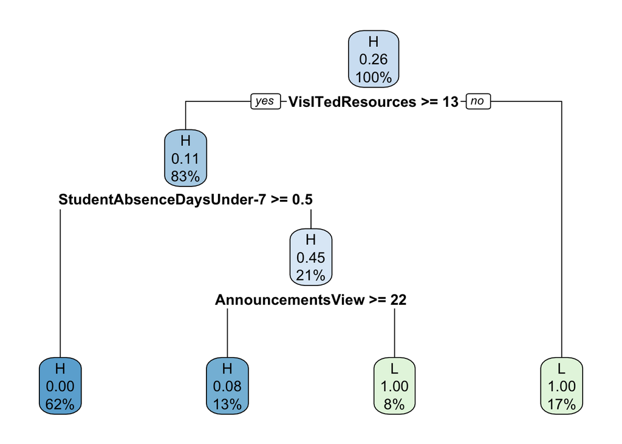

```r
rpart.plot(tree_model$finalModel)
```

Описание дерева:

```r
summary(tree_model)
```

[output not shown]

[output cut: 597 more lines]

```
##       NationalITyKW                < 0.5  to the left,  agree=0.85, adj=0.625, (0 split)
##       Discussion                   < 18.5 to the right, agree=0.85, adj=0.625, (0 split)
##       ParentschoolSatisfactionGood < 0.5  to the right, agree=0.85, adj=0.625, (0 split)
##       PlaceofBirthKuwaIT           < 0.5  to the left,  agree=0.80, adj=0.500, (0 split)
##       VisITedResources             < 36.5 to the right, agree=0.80, adj=0.500, (0 split)
##
## Node number 10: 12 observations
##   predicted class=H  expected loss=0.08333333  P(node) =0.1263158
##     class counts:    11     1
##    probabilities: 0.917 0.083
##
## Node number 11: 8 observations
##   predicted class=L  expected loss=0  P(node) =0.08421053
##     class counts:     0     8
##    probabilities: 0.000 1.000
```

- Упражнение 9.

Постройте дерево для набора данных `def`, визуализируйте результат и нарисуйте картинку.

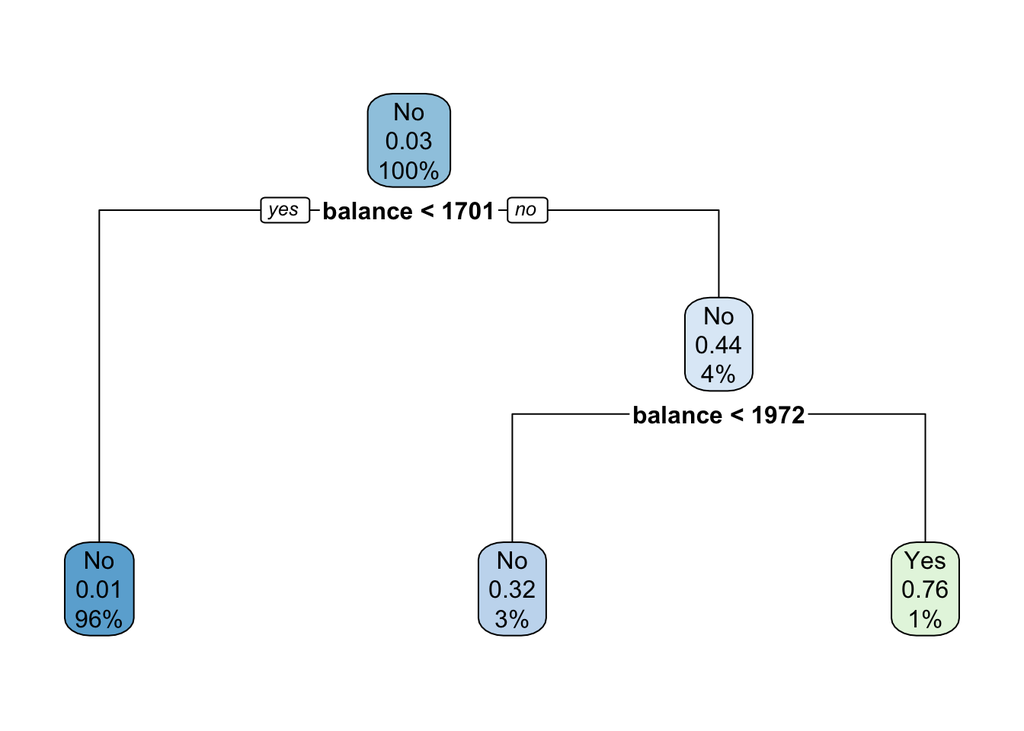

```r
def_tree <- train(data = def_train, default ~ ., method = 'rpart2')
rpart.plot(def_tree$finalModel)
```

```r
summary(def_tree)
```

[output not shown]

[output cut: 4320 more lines]

```
##   left son=6 (226 obs) right son=7 (82 obs)
##   Primary splits:
##       balance    < 1971.915 to the left,  improve=23.034800, (0 missing)
##       income     < 48861.49 to the left,  improve= 3.042984, (0 missing)
##       studentYes < 0.5      to the right, improve= 1.582551, (0 missing)
##
## Node number 6: 226 observations
##   predicted class=No   expected loss=0.3185841  P(node) =0.0322811
##     class counts:   154    72
##    probabilities: 0.681 0.319
##
## Node number 7: 82 observations
##   predicted class=Yes  expected loss=0.2439024  P(node) =0.01171261
##     class counts:    20    62
##    probabilities: 0.244 0.756
```

Предсказываем с помощью дерева на тестовой выборке:

```r
educ_tree <- mutate(educ_test,
  yhat = predict(tree_model, educ_test, na.action = na.pass))
confusionMatrix(educ_tree$yhat, educ_tree$y)
```

```
## Confusion Matrix and Statistics
##
##           Reference
## Prediction  H  L
##          H 70  1
##          L  0 24
##
##                Accuracy : 0.9895
##                  95% CI : (0.9427, 0.9997)
##     No Information Rate : 0.7368
##     P-Value [Acc > NIR] : 8.785e-12
##
##                   Kappa : 0.9725
##  Mcnemar's Test P-Value : 1
##
##             Sensitivity : 1.0000
##             Specificity : 0.9600
##          Pos Pred Value : 0.9859
##          Neg Pred Value : 1.0000
##              Prevalence : 0.7368
##          Detection Rate : 0.7368
##    Detection Prevalence : 0.7474
##       Balanced Accuracy : 0.9800
##
##        'Positive' Class : H
##
```

- Упражнение 10.

Постройте прогнозы с помощью дерева на тестовой выборке `def_test` и оцените его качество, посмотрев на матрицу ошибок.

```r
def_tree_pred <- mutate(def_test,
  yhat = predict(def_tree, def_test))
confusionMatrix(def_tree_pred$yhat, def_tree_pred$y)
```

[output not shown]

Пакет `caret` представляет собой общий интерфейс ко многим моделям, однако некоторые модели он ещё не поддерживает. Например, быстрые и стройные, [fast and frugal](https://cran.r-project.org/web/packages/FFTrees/vignettes/FFTrees_heart.html), деревья.

Быстрые деревья нужны, например, в медицине, чтобы создавать быстрые и простые рекомендации для спасения жизни.

Мы применим их для спасения неуспевающих студентов :) Увы, пакет принимает на вход только 0/1 в зависимой переменной, поэтому заменим названия категорий на числа:

```r
educ_train2 <- mutate(educ_train, ybin = ifelse(y == 'H', 1, 0)) %>%
select(-Class)
```

И построим картинку для быстрого и стройного дерева:

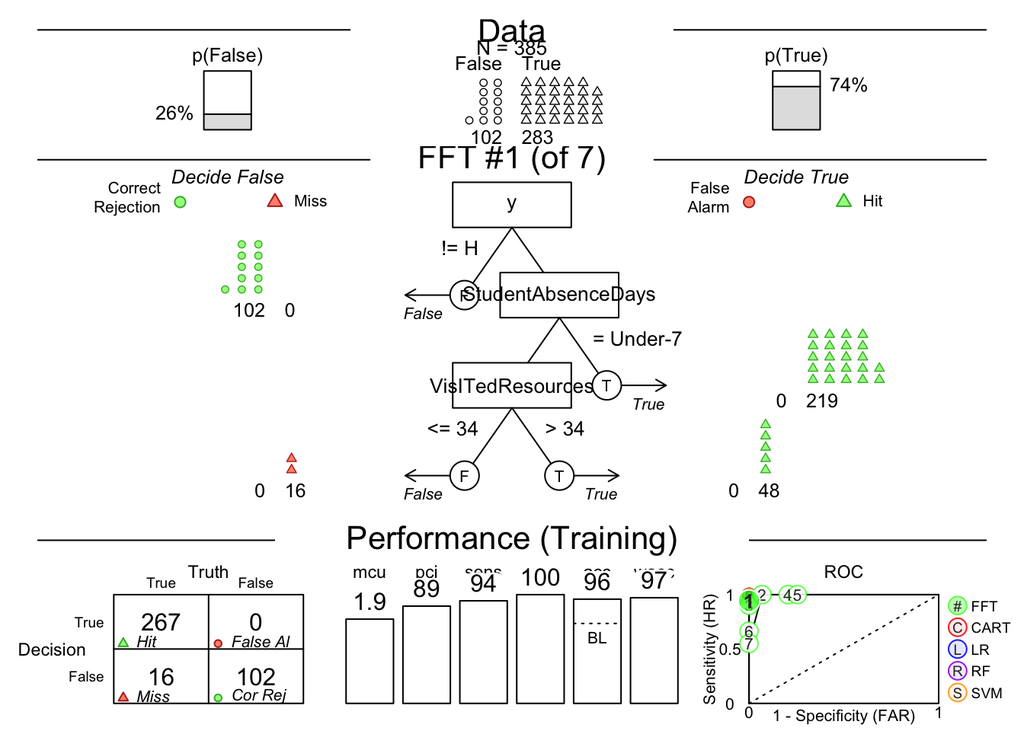

```r
fftree_model <- FFTrees(formula = ybin ~ .,
                     data = educ_train2)
plot(fftree_model)
```

- Упражнение 11.

Используйте быстрые и стройные деревья для набора данных `def_train`. Помните, что целевая переменная в нём закодирована как ‘Yes’ и ‘No’.

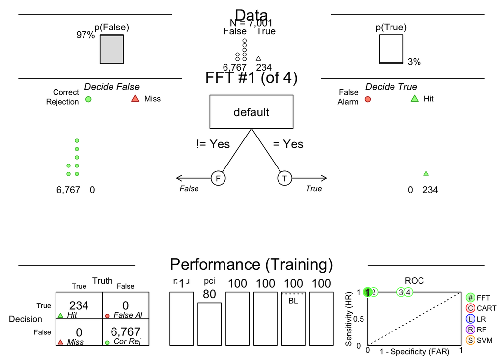

```r
def_train2 <- mutate(def_train, defaultbin = ifelse(default == 'Yes', 1, 0))

def_fftree <- FFTrees(formula = defaultbin ~ .,
                      data = def_train2)
plot(def_fftree)
```

# 3 Случайный лес

В алгоритме случайного леса мы

1. Выращиваем целый лес, скажем 500, деревьев.
2. Строим прогноз с помощью каждого дерева.
3. Агрегируем прогнозы деревьев. Можно в качестве итогового прогноза выбрать ту категорию, за которую проголосовало большинство деревьев. Можно оценить вероятности категорий, взяв процент деревьев, проголосовавших за ту или иную категорию.

Деревья оказываются не идеальными копиями друг друга по двум причинам:

1. Каждое дерево обучается на случайной выборке из исходной выборки. Обычно для каждого дерева берут подвыборку с повторениями из исходной выборки, так чтобы размер подвыборки равнялся размеру исходной выборки.
2. При каждом делении каждой ветки на две части происходит предварительный случайный отбор переменных. Скажем, из исходных 100 переменных, каждый раз случайно отбирается 10, а затем из этих 10 выбирается наилучшая, по которой ветвь и делится на две ветви.

У идеи есть куча вариантов исполнения, отличающихся деталями:

- критерием деления ветви на две;
- критерием остановки деления дерева;
- количеством предварительно отбираемых переменных перед каждым делением;
- количество деревьев;

Посмотрим на все вариации случайного леса, которые перебрал `ranger`.

```r
ranger_model <- train(y ~ . - Class, data = educ_test,
                    method = 'ranger',
                    na.action = na.omit,
                    importance = 'impurity')
ranger_model
```

```
## Random Forest
##
## 95 samples
## 17 predictors
##  2 classes: 'H', 'L'
##
## No pre-processing
## Resampling: Bootstrapped (25 reps)
## Summary of sample sizes: 95, 95, 95, 95, 95, 95, ...
## Resampling results across tuning parameters:
##
##   mtry  splitrule   Accuracy   Kappa
##    2    gini        0.7907616  0.3251077
##    2    extratrees  0.7631666  0.2021327
##   31    gini        0.9334543  0.8241534
##   31    extratrees  0.9404518  0.8446664
##   60    gini        0.9110362  0.7705113
##   60    extratrees  0.9341915  0.8287680
##
## Tuning parameter 'min.node.size' was held constant at a value of 1
## Accuracy was used to select the optimal model using the largest value.
## The final values used for the model were mtry = 31, splitrule =
##  extratrees and min.node.size = 1.
```

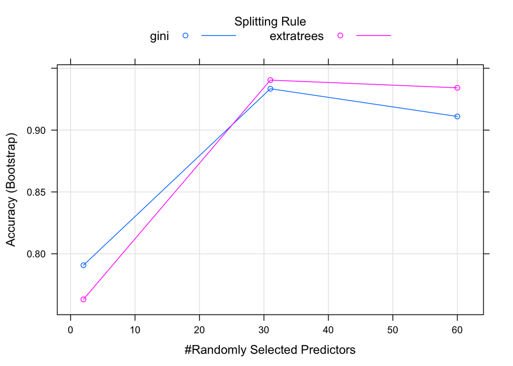

```r
plot(ranger_model)
```

И более подробно про наилучшую:

```r
ranger_model$finalModel
```

```
## Ranger result
##
## Call:
##  ranger::ranger(dependent.variable.name = ".outcome", data = x,      mtry = param$mtry, min.node.size = param$min.node.size, splitrule = as.character(param$splitrule),      write.forest = TRUE, probability = classProbs, ...)
##
## Type:                             Classification
## Number of trees:                  500
## Sample size:                      95
## Number of independent variables:  60
## Mtry:                             31
## Target node size:                 1
## Variable importance mode:         impurity
## Splitrule:                        extratrees
## OOB prediction error:             3.16 %
```

- Упражнение 12.

Реализуйте случайный лес для данных про кредиты, выведите описание лучешй модели и постройте визуализацию.

```r
def_ranger <- train(default ~ ., data = def_train,
                    method = 'ranger',
                    importance = 'impurity')
def_ranger$finalModel
```

```
## Ranger result
##
## Call:
##  ranger::ranger(dependent.variable.name = ".outcome", data = x,      mtry = param$mtry, min.node.size = param$min.node.size, splitrule = as.character(param$splitrule),      write.forest = TRUE, probability = classProbs, ...)
##
## Type:                             Classification
## Number of trees:                  500
## Sample size:                      7001
## Number of independent variables:  3
## Mtry:                             2
## Target node size:                 1
## Variable importance mode:         impurity
## Splitrule:                        extratrees
## OOB prediction error:             3.16 %
```

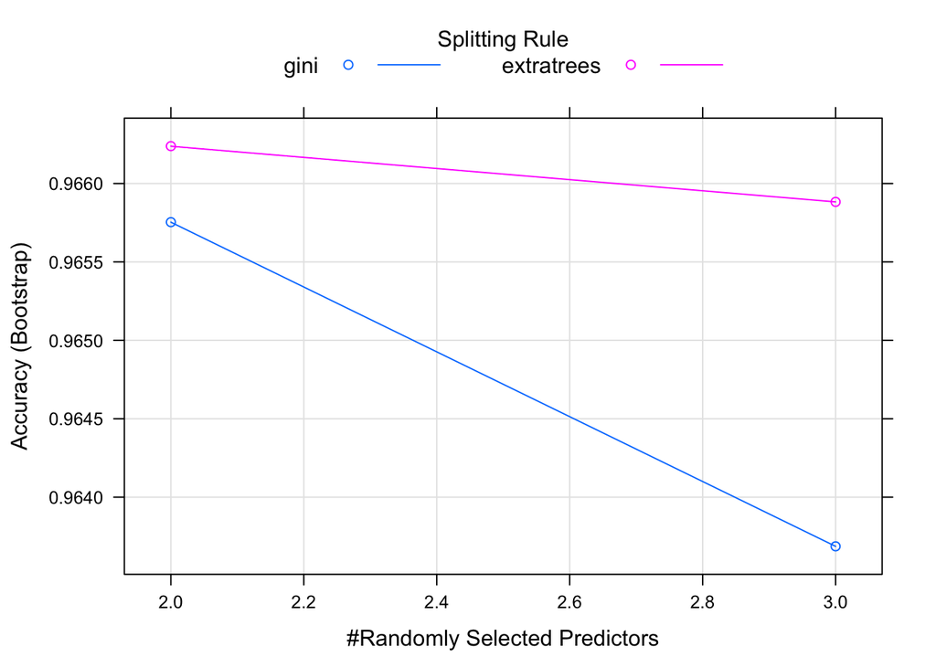

```r
plot(def_ranger)
```

К сожалению, построить информативно про все сотни деревьев невозможно.

Можно попытаться выделить важность переменных:

```r
ranger_import <- varImp(ranger_model)
ranger_import
```

```
## ranger variable importance
##
##   only 20 most important variables shown (out of 60)
##
##                              Overall
## VisITedResources             100.000
## StudentAbsenceDaysUnder-7     98.657
## AnnouncementsView             46.757
## ParentschoolSatisfactionGood  24.153
## raisedhands                   22.050
## Discussion                    14.379
## ParentAnsweringSurveyYes      10.912
## PlaceofBirthKuwaIT             7.643
## PlaceofBirthJordan             5.590
## genderM                        5.166
## GradeIDG-07                    4.608
## GradeIDG-04                    4.264
## NationalITyJordan              4.029
## SectionIDB                     3.959
## TopicMath                      3.890
## NationalITyKW                  3.681
## TopicScience                   3.257
## TopicIT                        3.232
## StageIDlowerlevel              3.141
## TopicEnglish                   2.324
```

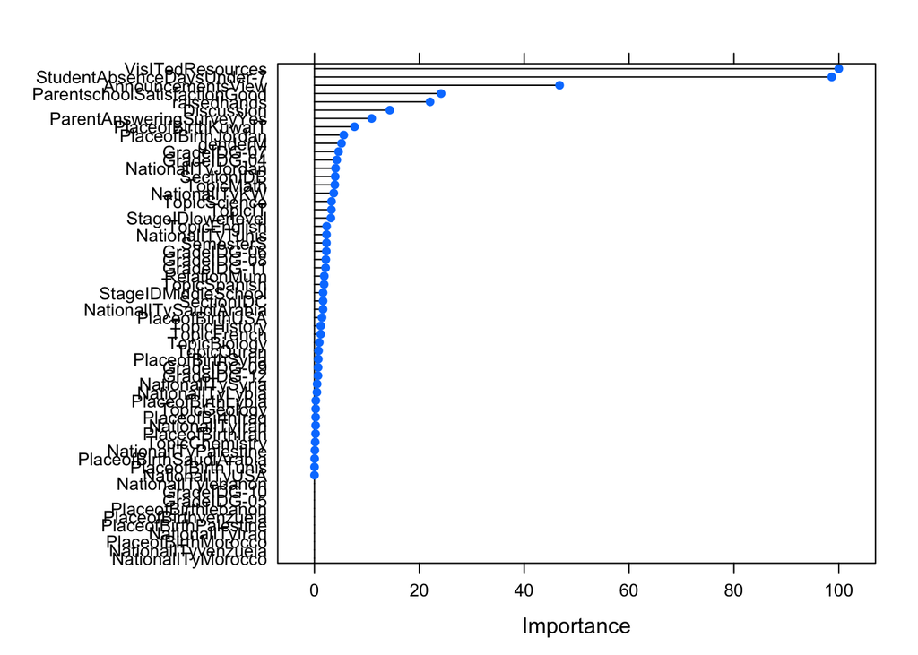

```r
plot(ranger_import)
```

- Упражнение 13.

Выделите важность переменных в модели `def_ranger`.

```r
def_import <- varImp(def_ranger)
def_import
```

```
## ranger variable importance
##
##            Overall
## balance     100.00
## income       50.62
## studentYes    0.00
```

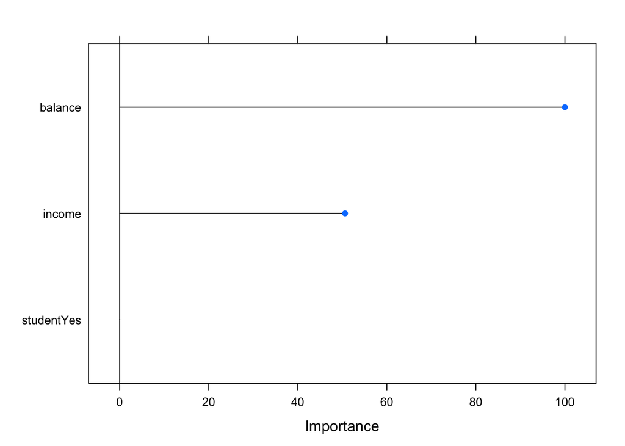

```r
plot(def_import)
```

И, конечно, построить прогнозы:

```r
educ_ranger <- mutate(educ_test,
  yhat = predict(ranger_model, educ_test, na.action = na.pass))
confusionMatrix(educ_ranger$yhat, educ_ranger$y)
```

```
## Confusion Matrix and Statistics
##
##           Reference
## Prediction  H  L
##          H 70  0
##          L  0 25
##
##                Accuracy : 1
##                  95% CI : (0.9619, 1)
##     No Information Rate : 0.7368
##     P-Value [Acc > NIR] : 2.515e-13
##
##                   Kappa : 1
##  Mcnemar's Test P-Value : NA
##
##             Sensitivity : 1.0000
##             Specificity : 1.0000
##          Pos Pred Value : 1.0000
##          Neg Pred Value : 1.0000
##              Prevalence : 0.7368
##          Detection Rate : 0.7368
##    Detection Prevalence : 0.7368
##       Balanced Accuracy : 1.0000
##
##        'Positive' Class : H
##
```

По умолчанию, пакет `caret` сам решает, сколько значений параметров перебирать и какие конкретно.

Список перебираемых параметров:

```r
modelLookup(model = 'ranger')
```

```
##    model     parameter                         label forReg forClass
## 1 ranger          mtry #Randomly Selected Predictors   TRUE     TRUE
## 2 ranger     splitrule                Splitting Rule   TRUE     TRUE
## 3 ranger min.node.size             Minimal Node Size   TRUE     TRUE
##   probModel
## 1      TRUE
## 2      TRUE
## 3      TRUE
```

Но мы можем заказать перебор любых.

Можно заказать количество перебираемых значений для каждого параметра:

```r
ranger_model <- train(y ~ . - Class, data = educ_test,
                      method = "ranger",
                      na.action = na.omit,
                      importance = 'impurity',
                      tuneLength = 4)
```

Или явно значения

```r
grid <- expand.grid(mtry = c(5, 10), min.node.size = c(1, 5), splitrule = 'gini')

ranger_model <- train(y ~ . - Class, data = educ_test,
            tuneGrid = grid, method = "ranger", na.action = na.omit)
ranger_model
```

```
## Random Forest
##
## 95 samples
## 17 predictors
##  2 classes: 'H', 'L'
##
## No pre-processing
## Resampling: Bootstrapped (25 reps)
## Summary of sample sizes: 95, 95, 95, 95, 95, 95, ...
## Resampling results across tuning parameters:
##
##   mtry  min.node.size  Accuracy   Kappa
##    5    1              0.9419550  0.8464319
##    5    5              0.9304239  0.8100096
##   10    1              0.9431248  0.8506694
##   10    5              0.9462449  0.8584092
##
## Tuning parameter 'splitrule' was held constant at a value of gini
## Accuracy was used to select the optimal model using the largest value.
## The final values used for the model were mtry = 10, splitrule = gini
##  and min.node.size = 5.
```

Ура :)